# Time Series - EXAM

Samd Guizani

2025-01-03

# Assignment

- File 2023-11-Elec-train.xlsx contains electricity consumption (kW) and outdoor air temperature for a building., measured every 15 minutes, from 1/1/2010 1:15 to 2/20/2010 23:45.
- In addition, outdoor air temperature are available for 2/21/2010. The goal is to forecast electricity consumption (kW) for 2/21/2010.
- Two forecasts should be returned, in one Excel file entitled YourName.xlsx, with exactly two columns (one columns per forecast) and 96 rows:
  1. first one without using outdoor temperature
  2. the second one using outdoor temperature.

# Working directory and imports

```r
setwd("~/DSTI_MSc DS and AI/03-Advanced/03-Time Series/Exam")

library(readxl)
library(forecast)
```

```r
library(funtimes) # trend tests
library(ggplot2)
library(imputeTS) # imputing missing data in a time series (interpolation)
library(randomForest)
library(xgboost)
library(e1071) # SVM
library(vars) # VAR model
library(writexl)
```

# Functions

```r
## Forecast Time Series Using a Machine Learning Model

forecast_ML = function(fit, newdata, h)
  #' @description Time series forecast using a machine learning model (e.g., random forest or XGBoost). Iteratively predicts future values based on previous predictions and updates the input data matrix accordingly.
  #'
  #' @param fit A trained machine learning model (e.g., random forest, XGBoost) with a `predict` method.
  #'
  #' @param newdata A matrix of shape (1 x n) used as input to make the initial prediction. The matrix is updated iteratively for subsequent predictions.
  #'
  #' @param h An integer specifying the forecast horizon (number of future steps to predict).
  #'
  #' @return A numeric vector of length `h` containing the forecasted time series.
{
  prev = rep(NULL, h)
  for (t in 1:h) {
    prev[t] = predict(fit, newdata = newdata)
    newdata = matrix(c(newdata[-1], prev[t]), 1)
  }
  return(prev)
}


## Forecast Time Series Using a Machine Learning Model and covariates

forecast_ML_X = function(fit, newdata, h, xreg)
  #' @description Time series forecast using a machine learning model (e.g., random forest or XGBoost). Iteratively predicts future values based on previous predictions and measured covariates and updates the input data matrix accordingly.
  #'
  #' @param fit A trained machine learning model (e.g., random forest, XGBoost) with a `predict` method.
  #'
  #' @param newdata A matrix of shape (1 x n) used as input to make the initial prediction. The matrix is updated iteratively for subsequent predictions.
  #'
  #' @param h An integer specifying the forecast horizon (number of future steps to predict).
  #'
  #' @param xreg A matrix containing the observed covariates to be used for the prediction.
  #'
  #' @return A numeric vector of length `h` containing the forecasted time series.
{
  newdata = matrix(c(newdata, xreg[1]), 1)

  prev = rep(NULL, h)
  prev[1] = predict(fit, newdata = newdata)

  for (t in 2:h)
    {
    newdata = newdata[1,-1]
    newdata[h] = prev[t-1]
    newdata = matrix(c(newdata, xreg[t]), 1)
    prev[t] = predict(fit, newdata = newdata)
    }
  return(prev)
}


## Root Mean Squared Error

RMSE = function(y_act, y_prd, na.rm = FALSE)
  #' @description Computes Root Mean Squared Error (RMSE) between actual and predicted values.
  #'
  #' @param y_act Numeric vector. Actual observed values.
  #' @param y_prd Numeric vector. Predicted values.
  #' @param rm.na Bool.  Whether NA values should be stripped before the computation proceeds (Default = FALSE)
  #'
  #' @return Float. Representing RMSE.
{
  return(sqrt(mean((y_act - y_prd)^2, na.rm = na.rm)))
}
```

# Load data and explore

## Plot time series and evaluate trends and seasonality patterns

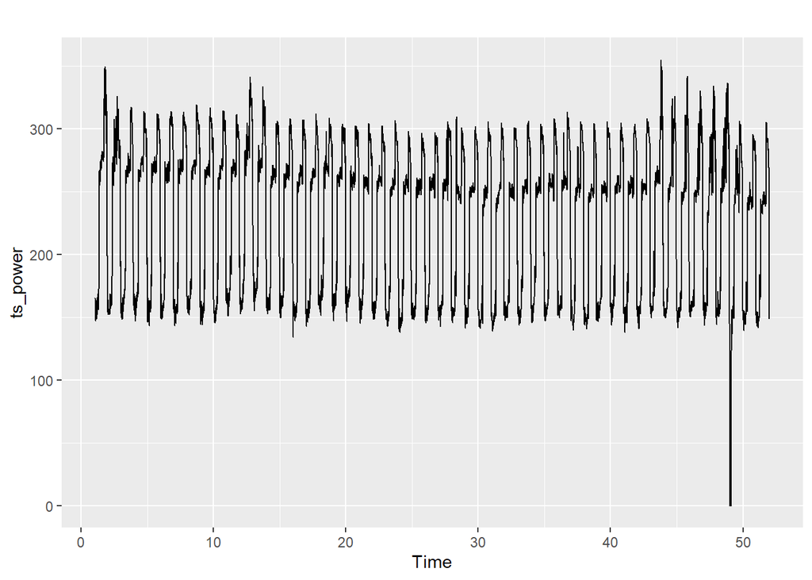

```r
data = read_excel('2023-11-Elec-train.xlsx')
data$Timestamp <- as.POSIXct(data[[1]], format = "%m/%d/%Y %H:%M")
data$Timestamp[1] <- as.POSIXct("1/1/2010 1:15", format = "%m/%d/%Y %H:%M") # fix import issue with 1st timestamp.

ts_power = ts(data$`Power (kW)`[1:(dim(data)[1] - 96)], start = c(1,6), freq = 96) # last 96 obs are NA, to be forecasted

autoplot(ts_power)
```

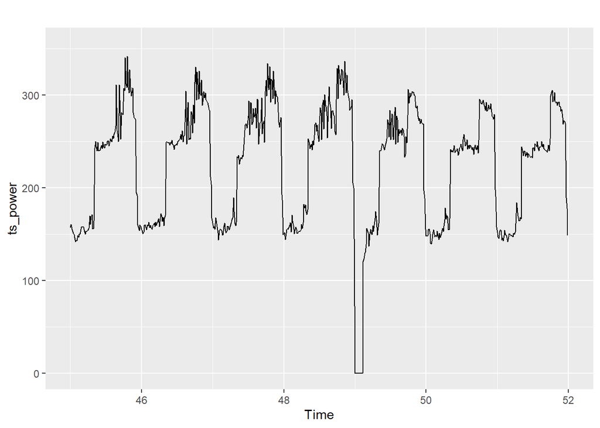

```r
autoplot(ts_power) + xlim(c(45, 52)) # focus on unusual data
```

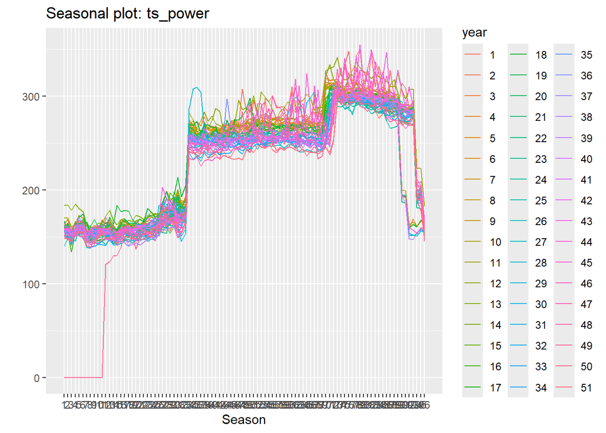

```r
ggseasonplot(ts_power) # seasonal plot with daily period
```

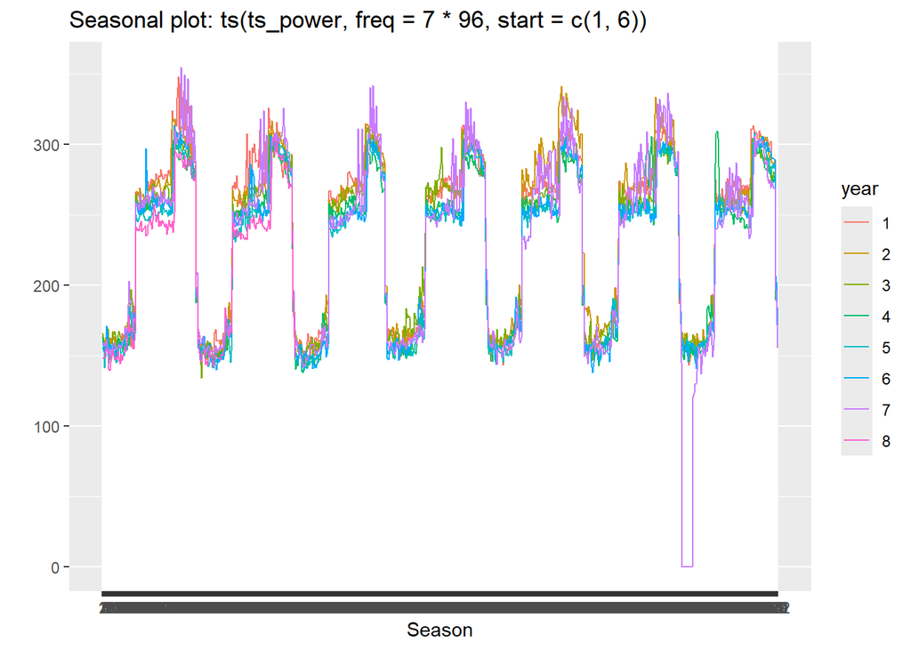

```r
ggseasonplot(ts(ts_power, freq = 7 * 96, start = c(1,6))) # seasonal plot with weekly period
```

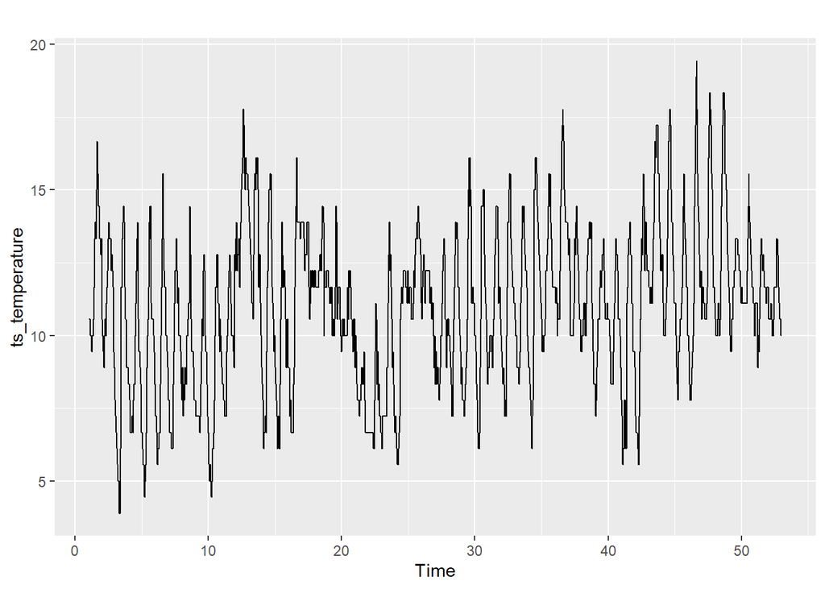

```r
ts_temperature = ts(data$`Temp (C°)`, start = c(1,6), freq = 96)
autoplot(ts_temperature)
```

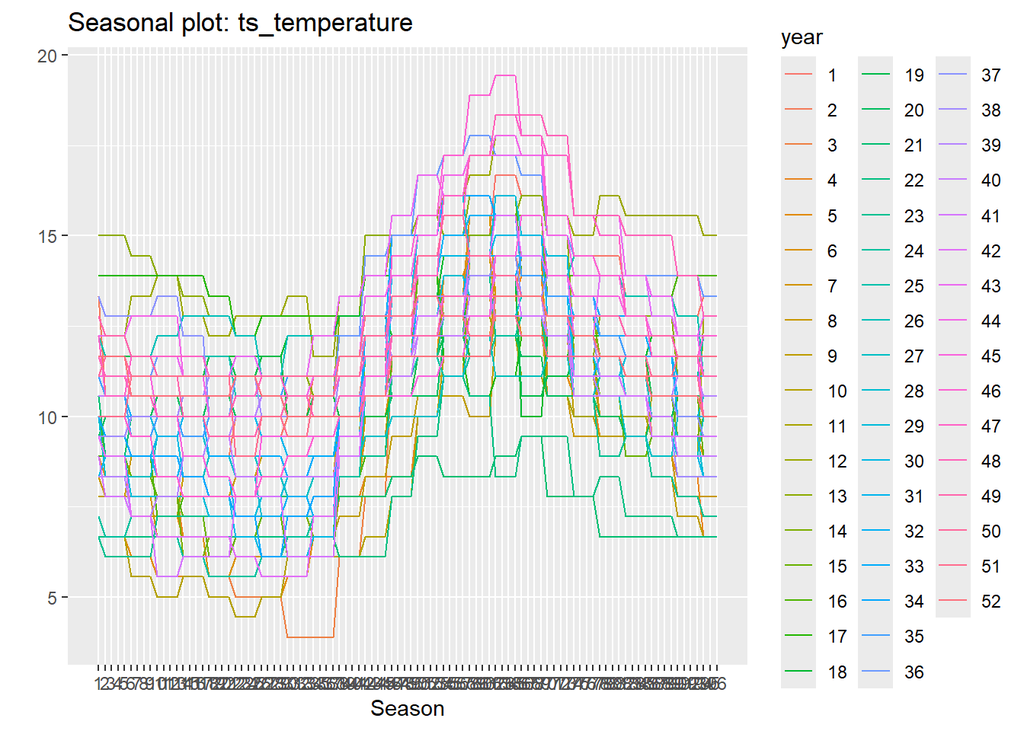

```r
ggseasonplot(ts_temperature)
```

#### Notes:

- Power shows a daily and weekly periodic pattern. Possibly a slight decreasing trend. Variance seems constant over time. Unusual zero values on day 49 (i.e. 2/18/2010) and unusual peak of power consumption on day 28 (i.e. 1/28/2010).
- Temperature shows a daily periodic pattern and an increasing trend.

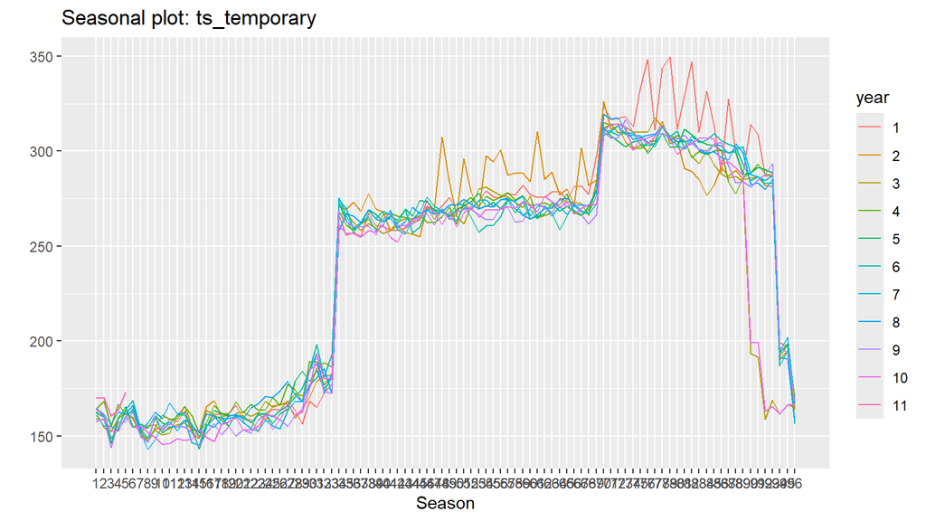

```r
n_days = 10
ts_temporary = ts(data$`Power (kW)`[1:(96*n_days)], start = c(1,6), freq = 96)
ggseasonplot(ts_temporary) #+ xlim(0.75,1)
```

## Replace unusual values by interpolation

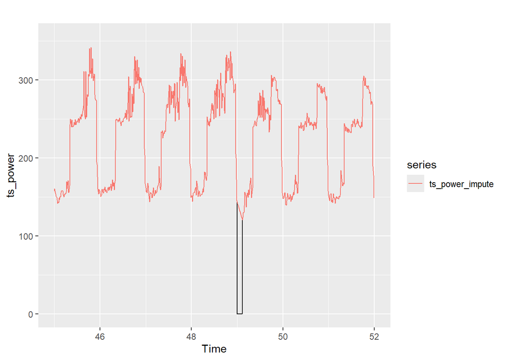

```r
# focus on power values at zero
loc_0s = which(ts_power == 0)
ts_power_impute = ts_power
ts_power_impute[loc_0s] = NA
ts_power_impute = imputeTS::na_interpolation(ts_power_impute, option = 'linear')

autoplot(ts_power) +
  autolayer(ts_power_impute) +
  xlim(c(45, 52))
```

```r
ts_power_impute[loc_0s]
```

```
##  [1] 143.2417 141.1833 139.1250 137.0667 135.0083 132.9500 130.8917 128.8333
##  [9] 126.7750 124.7167 122.6583
```

#### Notes:

- Replacing 0 values by interpolated values seems reasonable.

## Time series decomposition and differentiating

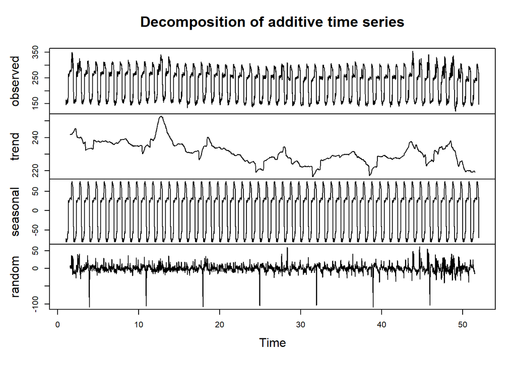

```r
plot(decompose(ts_power_impute)) # daily period
```

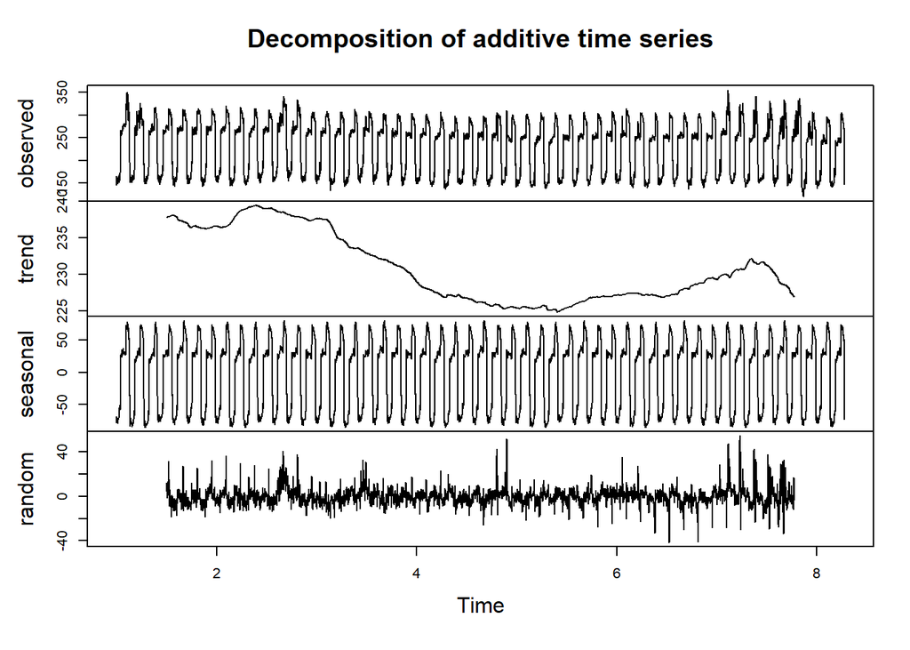

```r
plot(decompose(ts(ts_power_impute, frequency = 7*96))) # weekly period
```

#### Notes:

- Decomposing based on **daily** period: still a seasonal pattern in the random series (period of 7 days, i.e. weekly) as well as in the trend component.
- Decomposing based on **weekly** period: trend component looks smooth with no seasonal pattern. Random component still shows daily pattern (-> information need to be modeled)

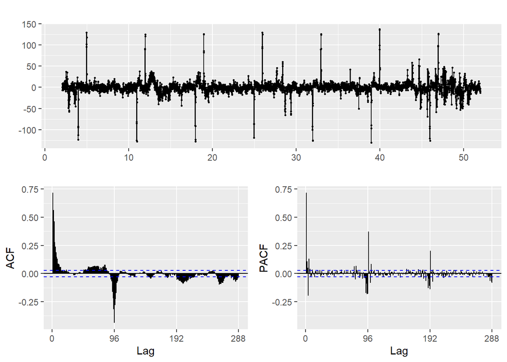

```r
ggtsdisplay(diff(ts_power_impute, lag = 96, differences = 1)) # daily period
```

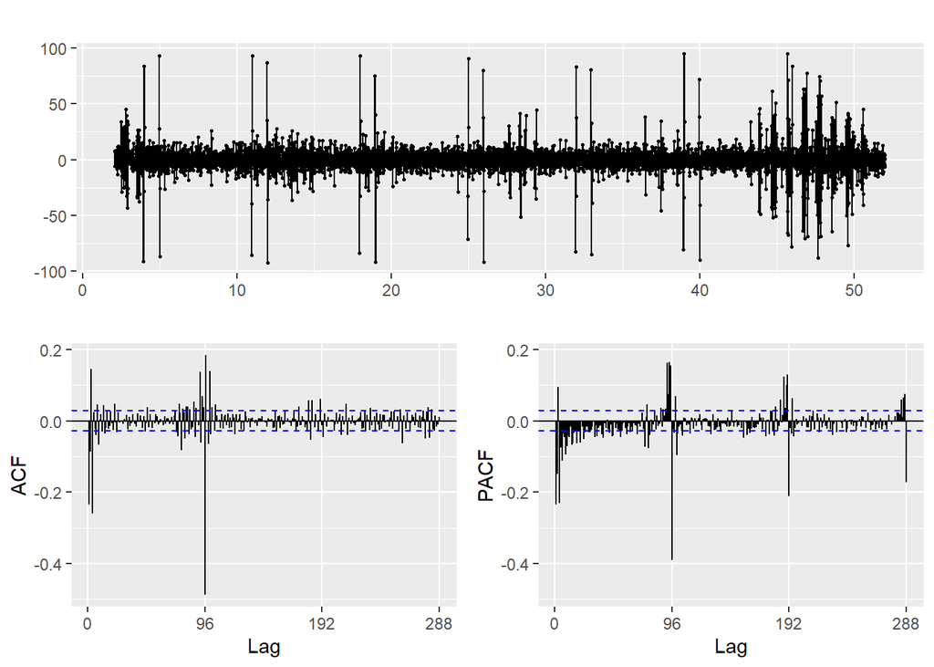

```r
ggtsdisplay(diff(diff(ts_power_impute, lag = 96, differences = 1),
                 lag = 1,
                 differences = 1)) # daily period + diff with lag 1
```

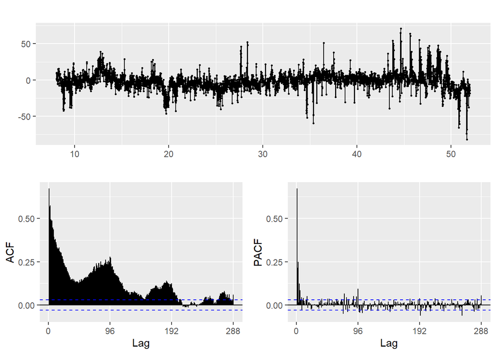

```r
ggtsdisplay(diff(ts_power_impute, lag = 7 * 96, differences = 1)) # weekly period
```

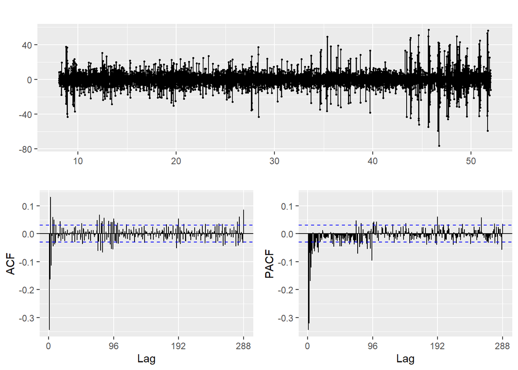

```r
ggtsdisplay(diff(diff(ts_power_impute, lag = 7 * 96, differences = ),
                 lag = 1,
                 differences = 1)) # weekly period + diff with lag 1
```

#### Notes:

- Differentiating with a lag = 1 day period: still observe a weekly seasonal pattern (see time series plot)
- Differentiating twice (with a lag = 1 day period + lag = 1 for de-trending): still observe a weekly seasonal pattern (see time series plot)
- Differentiating with a lag = 1 week period: periodic pattern no longer observed, but a trend is still visible (see time series plot).
- Differentiating twice (with a lag = 1 week period + lag = 1 for de-trending): time series centered on 0, no visible trend. ACF/PACF show significant autocorrelation values (-> information to be modeled)

# Modeling, without co-variates

```r
# Converting ts_power_impute to daily period
y_daily = ts(ts_power_impute, start = c(1,6), frequency = 96)
y_daily_train = head(y_daily, length(y_daily) - 96)
y_daily_test = tail(y_daily, 96) # last day kept as test set

# Converting ts_power_impute to weekly period
y_weekly = ts(ts_power_impute, start = c(1,6), frequency = 7*96)
y_weekly_train = head(y_weekly, length(y_weekly) - 96)
y_weekly_test = tail(y_weekly, 96) # last day kept as test set
```

## Holt-Winters, Daily period

```r
# Code commented: Holt-Winters model failed to be fitted due to too large number of lags per period (96).

# exec_t_start = Sys.time()
#
# fit = hw(y_daily_train, h=96, seasonal = "additive")
# fit |>  summary()
#
# ggtsdisplay(fit$residuals)
# checkresiduals(fit, plot = TRUE)
#
# exec_t_end = Sys.time()
# print(exec_t_end - exec_t_start)
```

#### Notes:

- Holt-Winters model fitting fails due to too high frequency (96).

## SARIMA (auto), Daily period

```r
# Auto SARIMA, daily period
exec_t_start = Sys.time()

fit = auto.arima(y_daily_train)
fit |>  summary()
```

```
## Series: y_daily_train
## ARIMA(5,0,0)(0,1,0)[96]
##
## Coefficients:
##          ar1     ar2     ar3      ar4     ar5
##       0.6705  0.0671  0.1623  -0.2823  0.1330
## s.e.  0.0145  0.0170  0.0168   0.0170  0.0145
##
## sigma^2 = 122.7:  log likelihood = -17966.78
## AIC=35945.56   AICc=35945.58   BIC=35984.29
##
## Training set error measures:
##                      ME     RMSE      MAE        MPE     MAPE      MASE
## Training set -0.1036317 10.96142 6.457121 -0.1529683 2.921813 0.7344067
##                      ACF1
## Training set 0.0005224987
```

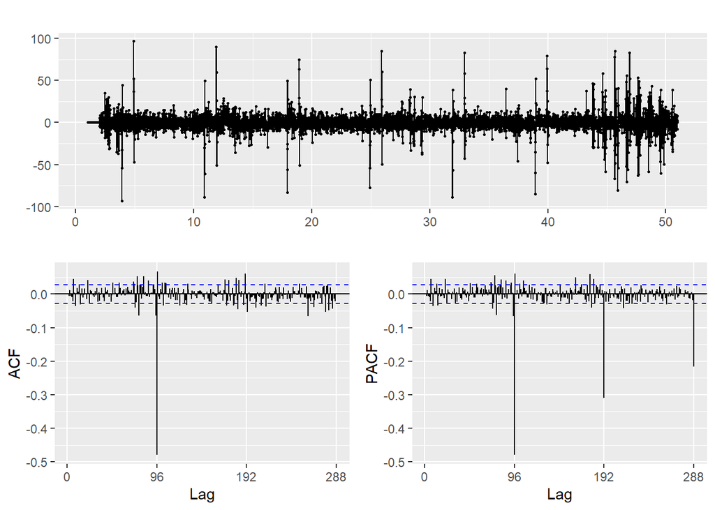

```r
ggtsdisplay(fit$residuals)
```

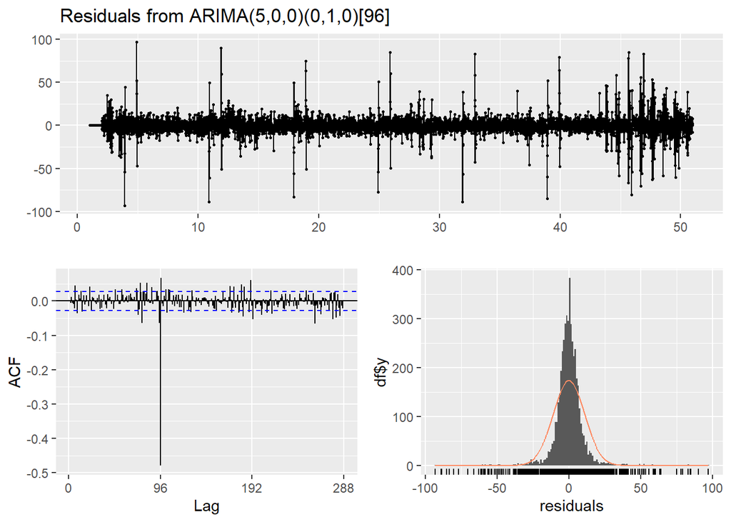

```
##
##  Ljung-Box test
##
## data:  Residuals from ARIMA(5,0,0)(0,1,0)[96]
## Q* = 1540.2, df = 187, p-value < 2.2e-16
##
## Model df: 5.   Total lags used: 192
```

```r
checkresiduals(fit, plot = TRUE)
```

```r
exec_t_end = Sys.time()
print(exec_t_end - exec_t_start)
```

```
## Time difference of 1.057395 mins
```

```r
# saveRDS(fit, file = "ARIMA_auto_(5,0,0)(0,1,0)[96].rds")
```

#### Notes:

- ACF shows significant autocorrelation at 96 (= 1 day period) and PACF shows exponentially decreasing autocorrelation for daily periods -> try adding seasonal MA (Q = 1)
- Some autocorrelation values are significant within the 1st period on ACF and PACF - > try changing the order p and q

### Cross-validation

```r
# Code commented: very long computation

# # Forcasting function to cross-validate
# Arima_ <- function(x, h) {
#   forecast(Arima(x,
#                  order=c(5,0,0),
#                  seasonal = c(0,1,0)
#                  ))
# }
#
# # Crossvalidation execution
# exec_t_start = Sys.time()
#
# e <- tsCV(y_daily, Arima_, h=96, window = 4795)
#
# exec_t_end = Sys.time()
# print(exec_t_end - exec_t_start)
#
# print(paste0("Cross-validation RMSE: ", sqrt(mean(e^2, na.rm = TRUE))))
```

#### Notes:

Cross-validation:

[output not shown]

## SARIMA (manual), Daily period

```r
# SARIMA, daily period
exec_t_start = Sys.time()

fit = Arima(y_daily_train, order = c(5,0,0), seasonal = c(0,1,1))
fit |>  summary()
```

```
## Series: y_daily_train
## ARIMA(5,0,0)(0,1,1)[96]
##
## Coefficients:
##          ar1     ar2     ar3      ar4     ar5     sma1
##       0.6729  0.0688  0.1632  -0.2361  0.1268  -0.8755
## s.e.  0.0145  0.0172  0.0170   0.0172  0.0145   0.0076
##
## sigma^2 = 67.66:  log likelihood = -16636.84
## AIC=33287.67   AICc=33287.7   BIC=33332.86
##
## Training set error measures:
##                    ME     RMSE      MAE        MPE     MAPE      MASE
## Training set -0.34689 8.137587 4.989581 -0.2607279 2.257775 0.5674946
##                      ACF1
## Training set -0.005121753
```

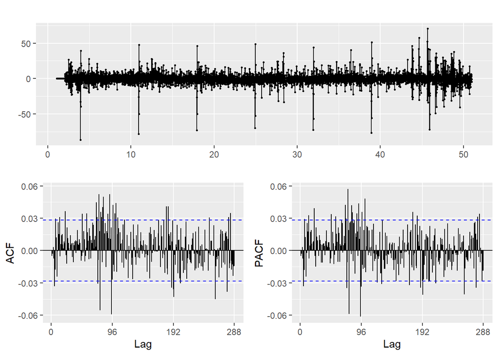

```r
ggtsdisplay(fit$residuals)
```

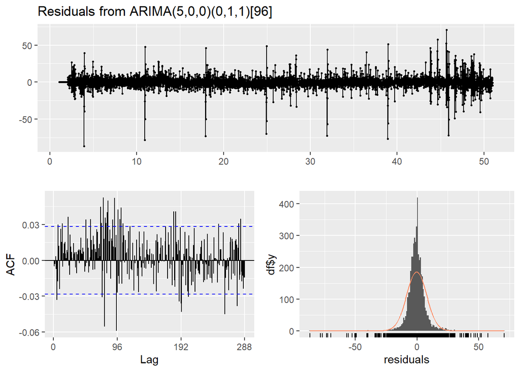

```
##
##  Ljung-Box test
##
## data:  Residuals from ARIMA(5,0,0)(0,1,1)[96]
## Q* = 347.46, df = 186, p-value = 7.013e-12
##
## Model df: 6.   Total lags used: 192
```

```r
checkresiduals(fit, plot = TRUE)
```

```r
exec_t_end = Sys.time()
print(exec_t_end - exec_t_start)
```

```
## Time difference of 3.555382 mins
```

```r
# saveRDS(fit, file = "ARIMA_man_(5,0,0)(0,1,1)[96].rds")
```

### Cross-validation

```r
# Code commented: very long computation

# # Cross validation using tsCV(), ref: https://pkg.robjhyndman.com/forecast/reference/tsCV.html
#
# # Forcasting function to cross-validate
# Arima_ <- function(x, h) {
#   forecast(Arima(x,
#                  order=c(5,0,0),
#                  seasonal = c(0,1,1)
#                  ))
# }
#
# # Crossvalidation execution
# exec_t_start = Sys.time()
#
# e <- tsCV(y_daily, Arima_, h=96, window = 4795)
#
# exec_t_end = Sys.time()
# print(exec_t_end - exec_t_start)
#
# print(paste0("Cross-validation RMSE: ", sqrt(mean(e^2, na.rm = TRUE))))
```

#### Notes:

Cross-validation:

```
Time difference of 5.734455 hours
[1] "Cross-validation RMSE: 12.5587524976877"
```

## NNetAR, Daily period

```r
exec_t_start = Sys.time()

fit = nnetar(y_daily_train)
fit |>  summary()
```

```
##           Length Class        Mode
## x         4795   ts           numeric
## m            1   -none-       numeric
## p            1   -none-       numeric
## P            1   -none-       numeric
## scalex       2   -none-       list
## size         1   -none-       numeric
## subset    4795   -none-       numeric
## model       20   nnetarmodels list
## nnetargs     0   -none-       list
## fitted    4795   ts           numeric
## residuals 4795   ts           numeric
## lags        26   -none-       numeric
## series       1   -none-       character
## method       1   -none-       character
## call         2   -none-       call
```

```r
e = fit$residuals
print(paste0("Train RMSE: ", sqrt(mean(e^2, na.rm = TRUE))))
```

```
## [1] "Train RMSE: 7.36936636232128"
```

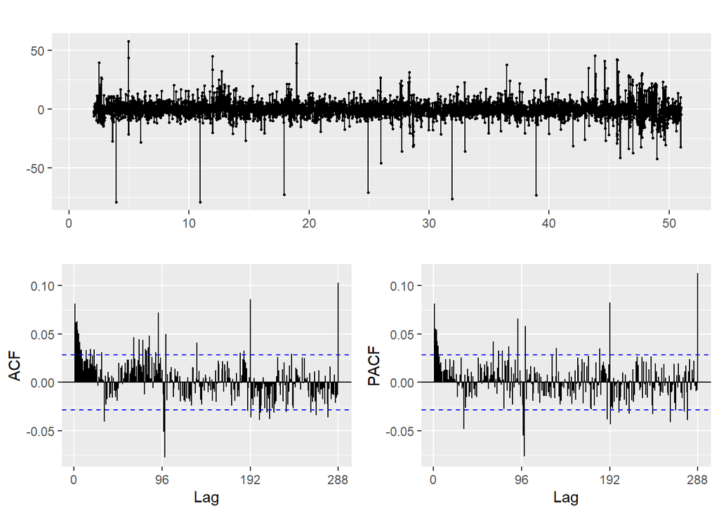

```r
ggtsdisplay(fit$residuals)
```

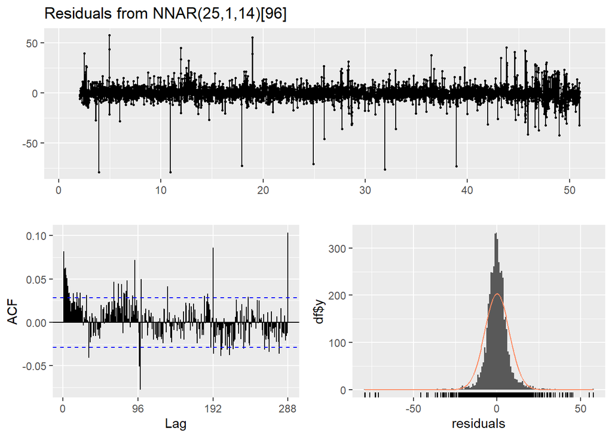

```
##
##  Ljung-Box test
##
## data:  Residuals from NNAR(25,1,14)[96]
## Q* = 495.37, df = 192, p-value < 2.2e-16
##
## Model df: 0.   Total lags used: 192
```

```r
checkresiduals(fit, plot = TRUE)
```

```r
exec_t_end = Sys.time()
print(exec_t_end - exec_t_start)
```

```
## Time difference of 46.29163 secs
```

```r
# saveRDS(fit, file = "NNetAR_daily.rds")
```

## SARIMA (auto), Weekly period

```r
# Code commented: long fitting time, model performance not great

# # Auto ARIMA, weekly period
# exec_t_start = Sys.time()
#
# fit = auto.arima(y_weekly_train)
# fit |>  summary()
#
# ggtsdisplay(fit$residuals)
# checkresiduals(fit, plot = TRUE)
#
# exec_t_end = Sys.time()
# print(exec_t_end - exec_t_start)
```

```r
# saveRDS(fit, file = "ARIMA_auto_(5,1,2)(0,1,0)[672].rds")
```

## SARIMA (manual), Weekly period

```r
# Code commented: fail to be fitted due to too large number of lags

# # ARIMA, weekly period
# exec_t_start = Sys.time()
#
# fit = Arima(y_weekly_train, order = c(5,1,2), seasonal = c(0,1,1))
# fit |>  summary()
#
# ggtsdisplay(fit$residuals)
# checkresiduals(fit, plot = TRUE)
#
# exec_t_end = Sys.time()
# print(exec_t_end - exec_t_start)
```

```r
# saveRDS(fit, file = "ARIMA_auto_(5,1,2)(0,1,1)[672].rds")
```

## NetAR, Weekly period

```r
exec_t_start = Sys.time()

fit = nnetar(y_weekly_train)
fit |>  summary()
```

```
##           Length Class        Mode
## x         4795   ts           numeric
## m            1   -none-       numeric
## p            1   -none-       numeric
## P            1   -none-       numeric
## scalex       2   -none-       list
## size         1   -none-       numeric
## subset    4795   -none-       numeric
## model       20   nnetarmodels list
## nnetargs     0   -none-       list
## fitted    4795   ts           numeric
## residuals 4795   ts           numeric
## lags        18   -none-       numeric
## series       1   -none-       character
## method       1   -none-       character
## call         2   -none-       call
```

```r
e = fit$residuals
print(paste0("Train RMSE: ", sqrt(mean(e^2, na.rm = TRUE))))
```

```
## [1] "Train RMSE: 6.35882115176639"
```

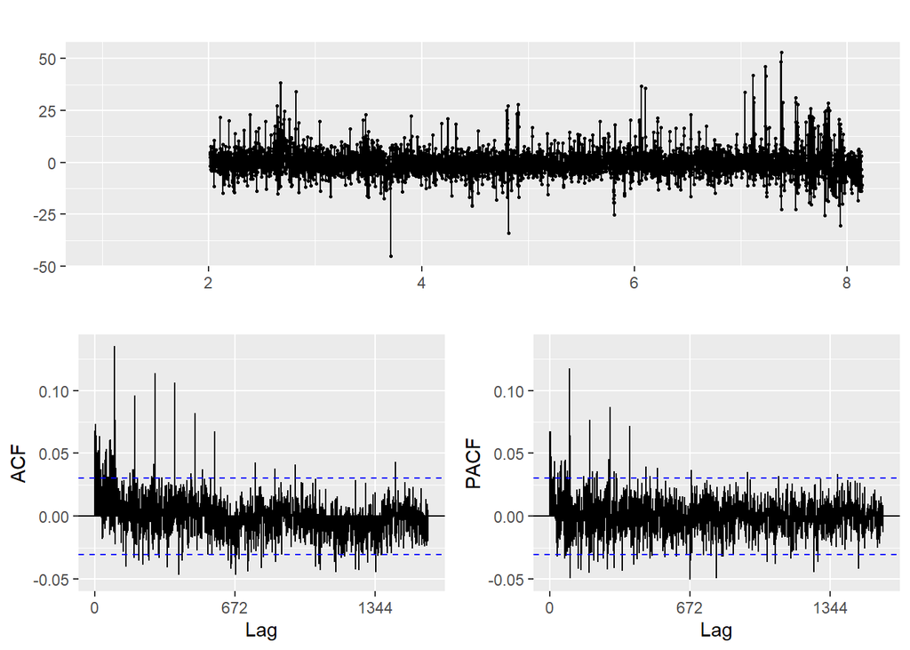

```r
ggtsdisplay(fit$residuals)
```

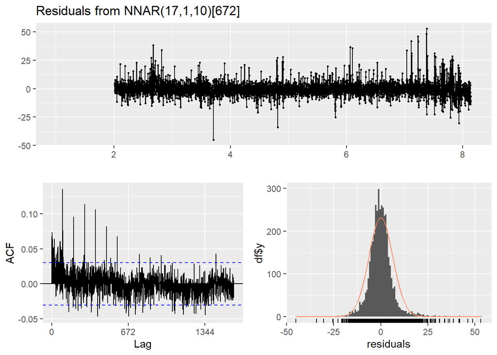

```
##
##  Ljung-Box test
##
## data:  Residuals from NNAR(17,1,10)[672]
## Q* = 1743.6, df = 959, p-value < 2.2e-16
##
## Model df: 0.   Total lags used: 959
```

```r
checkresiduals(fit, plot = TRUE)
```

```r
exec_t_end = Sys.time()
print(exec_t_end - exec_t_start)
```

```
## Time difference of 26.27995 secs
```

```r
# saveRDS(fit, file = "NNetAR_weekly.rds")
```

## ML data prep

```r
# next observation based on last day
df_daily = as.vector(y_daily_train)[1:(96+1)]
for (i in 1:(length(y_daily_train)-(96+1)))
{
  df_daily = rbind(df_daily, as.vector(y_daily_train)[(i+1):(i+96+1)])
}

# next observation based on last week
df_weekly = as.vector(y_weekly_train)[1:(7*96+1)]
for (i in 1:(length(y_weekly_train)-(7*96+1)))
{
  df_weekly = rbind(df_weekly, as.vector(y_weekly_train)[(i+1):(i+7*96+1)])
}

# next 96 observations based on 2 last week
df_2weeks = as.vector(y_weekly_train)[1:(2*7*96+96)]
for (i in 1:(length(y_weekly_train)-(2*7*96+96)))
{
  df_2weeks = rbind(df_2weeks, as.vector(y_weekly_train)[(i+1):(i+2*7*96+96)])
}
```

## ML - Random Forest, Daily period

```r
exec_t_start = Sys.time()

fit = randomForest(x = df_daily[,-(96+1)], y = df_daily[, (96+1)])
fit |>  summary()
```

```
##                 Length Class  Mode
## call               3   -none- call
## type               1   -none- character
## predicted       4699   -none- numeric
## mse              500   -none- numeric
## rsq              500   -none- numeric
## oob.times       4699   -none- numeric
## importance        96   -none- numeric
## importanceSD       0   -none- NULL
## localImportance    0   -none- NULL
## proximity          0   -none- NULL
## ntree              1   -none- numeric
## mtry               1   -none- numeric
## forest            11   -none- list
## coefs              0   -none- NULL
## y               4699   -none- numeric
## test               0   -none- NULL
## inbag              0   -none- NULL
```

```r
e = ts(fit$y - fit$predicted, start = c(1,6), frequency = 96)
print(paste0("Train RMSE: ", sqrt(mean(e^2, na.rm = TRUE))))
```

```
## [1] "Train RMSE: 7.28924430975706"
```

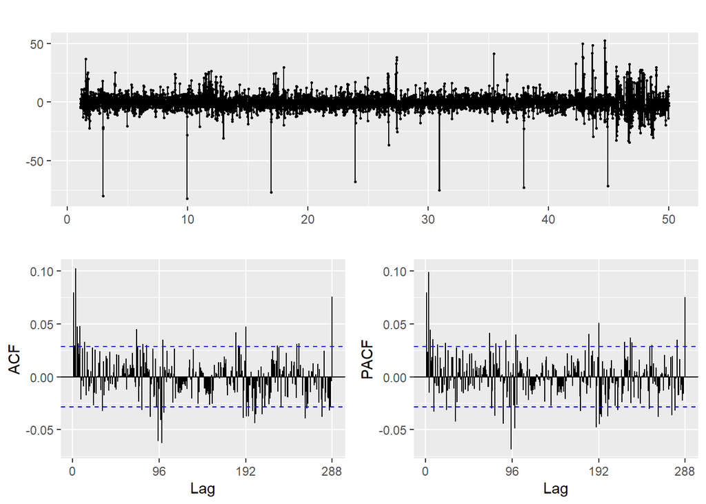

```r
ggtsdisplay(e)
```

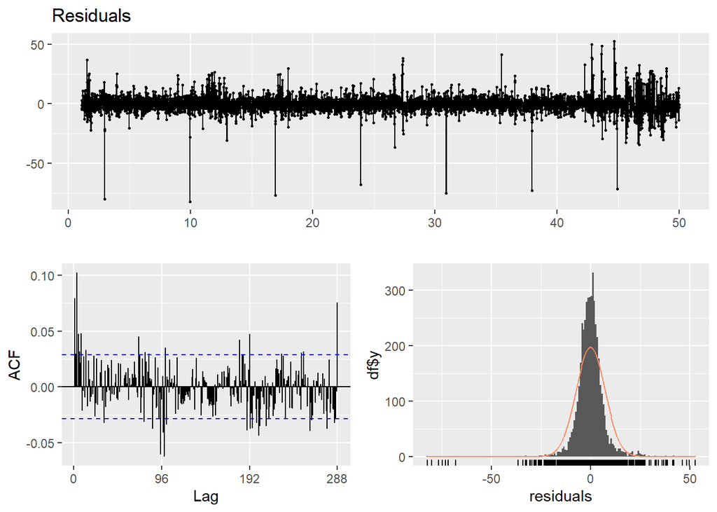

```
##
##  Ljung-Box test
##
## data:  Residuals
## Q* = 389.78, df = 192, p-value = 1.443e-15
##
## Model df: 0.   Total lags used: 192
```

```r
checkresiduals(e, plot = TRUE)
```

```r
exec_t_end = Sys.time()
print(exec_t_end - exec_t_start)
```

```
## Time difference of 1.442972 mins
```

```r
# saveRDS(fit, file = "RF_daily.rds")
```

## ML - XGBoost, Daily period

```r
exec_t_start = Sys.time()

fit = xgboost(data = df_daily[,-(96+1)], label = df_daily[, (96+1)],
              max_depth = 10,
              eta = 0.5,
              nrounds = 100,
              objective = "reg:squarederror")
fit |>  summary()
```

```
##                Length  Class              Mode
## handle               1 xgb.Booster.handle externalptr
## raw            1381676 -none-             raw
## niter                1 -none-             numeric
## evaluation_log       2 data.table         list
## call                16 -none-             call
## params               4 -none-             list
## callbacks            2 -none-             list
## nfeatures            1 -none-             numeric
```

```r
e = ts(df_daily[, (96+1)] - predict(fit, newdata = df_daily[,-(96+1)]), start = c(1,6), frequency = 96)
print(paste0("Train RMSE: ", sqrt(mean(e^2, na.rm = TRUE))))
```

```
## [1] "Train RMSE: 0.00816297752522528"
```

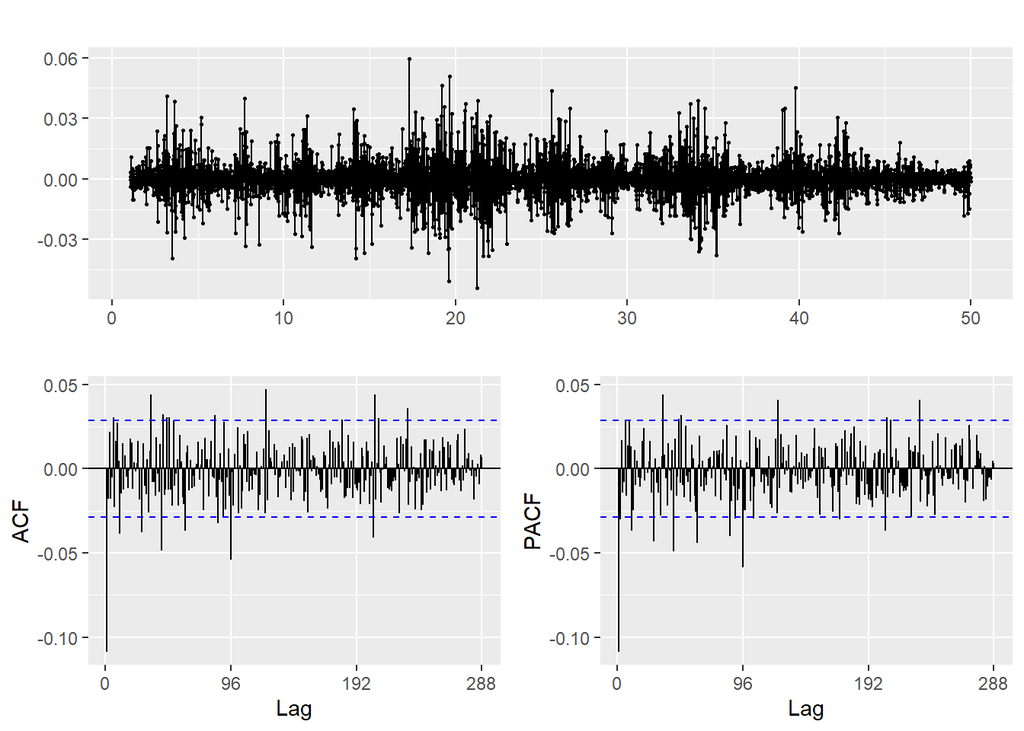

```r
ggtsdisplay(e)
```

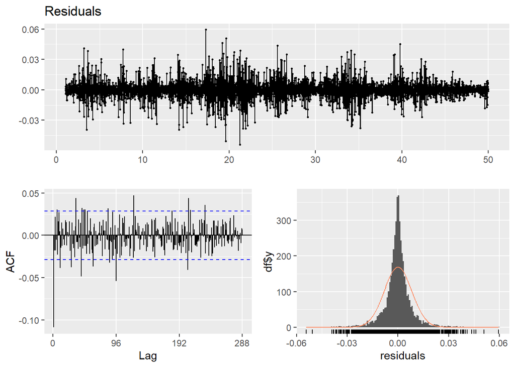

```
##
##  Ljung-Box test
##
## data:  Residuals
## Q* = 316.33, df = 192, p-value = 3.986e-08
##
## Model df: 0.   Total lags used: 192
```

```r
checkresiduals(e, plot = TRUE)
```

```r
exec_t_end = Sys.time()
print(exec_t_end - exec_t_start)
```

```
## Time difference of 7.328984 secs
```

```r
# saveRDS(fit, file = "XGBoost_daily.rds")
```

## ML - Random Forest, Weekly period

```r
exec_t_start = Sys.time()

fit = randomForest(x = df_weekly[,-(7*96+1)], y = df_weekly[, (7*96+1)])
fit |>  summary()
```

```
##                 Length Class  Mode
## call               3   -none- call
## type               1   -none- character
## predicted       4123   -none- numeric
## mse              500   -none- numeric
## rsq              500   -none- numeric
## oob.times       4123   -none- numeric
## importance       672   -none- numeric
## importanceSD       0   -none- NULL
## localImportance    0   -none- NULL
## proximity          0   -none- NULL
## ntree              1   -none- numeric
## mtry               1   -none- numeric
## forest            11   -none- list
## coefs              0   -none- NULL
## y               4123   -none- numeric
## test               0   -none- NULL
## inbag              0   -none- NULL
```

```r
e = ts(fit$y - fit$predicted, start = c(1,6), frequency = 96)
print(paste0("Train RMSE: ", sqrt(mean(e^2, na.rm = TRUE))))
```

```
## [1] "Train RMSE: 6.36450152436013"
```

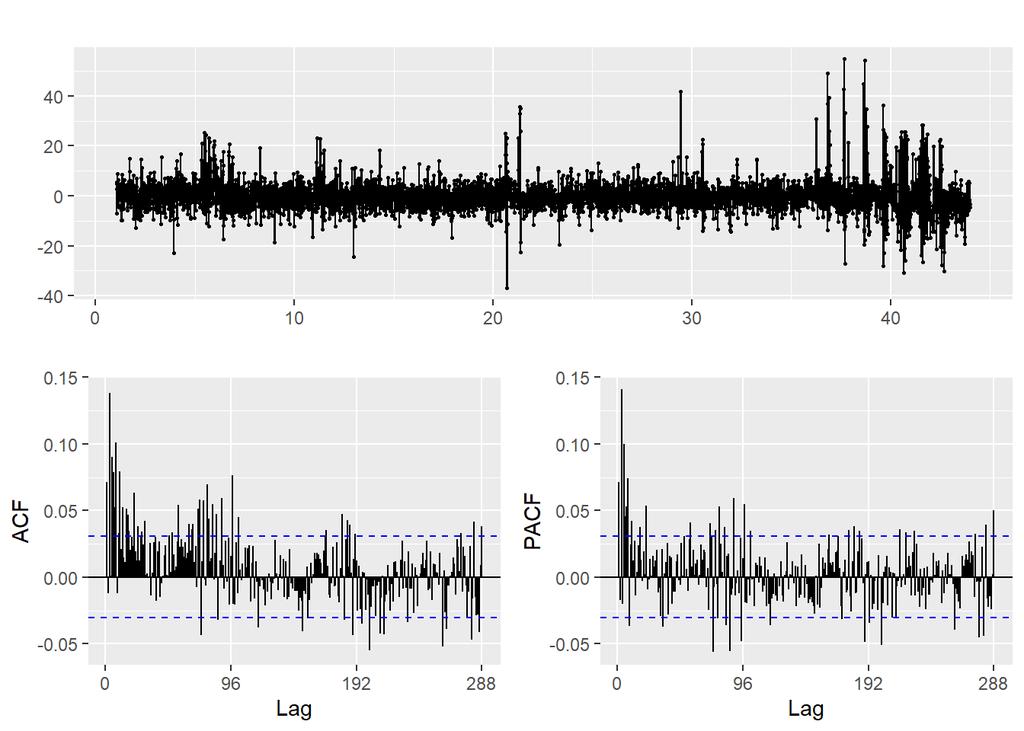

```r
ggtsdisplay(e)
```

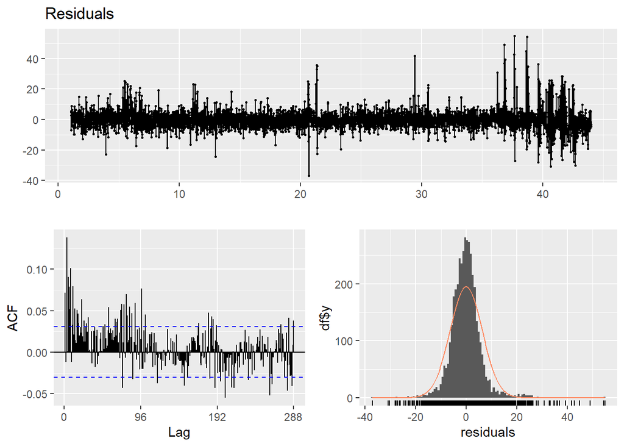

```
##
##  Ljung-Box test
##
## data:  Residuals
## Q* = 721.89, df = 192, p-value < 2.2e-16
##
## Model df: 0.   Total lags used: 192
```

```r
checkresiduals(e, plot = TRUE)
```

```r
exec_t_end = Sys.time()
print(exec_t_end - exec_t_start)
```

```
## Time difference of 7.877153 mins
```

```r
# saveRDS(fit, file = "RF_weekly.rds")
```

## ML - XGBoost, Weekly period

```r
exec_t_start = Sys.time()

fit = xgboost(data = df_weekly[,-(7*96+1)], label = df_weekly[, (7*96+1)],
              max_depth = 10,
              eta = 0.5,
              nrounds = 100,
              objective = "reg:squarederror")
fit |>  summary()
```

```
##                Length Class              Mode
## handle              1 xgb.Booster.handle externalptr
## raw            641571 -none-             raw
## niter               1 -none-             numeric
## evaluation_log      2 data.table         list
## call               16 -none-             call
## params              4 -none-             list
## callbacks           2 -none-             list
## nfeatures           1 -none-             numeric
```

```r
e = ts(df_weekly[, (7*96+1)] - predict(fit, newdata = df_weekly[,-(7*96+1)]), start = c(1,6), frequency = 96)
print(paste0("Train RMSE: ", sqrt(mean(e^2, na.rm = TRUE))))
```

```
## [1] "Train RMSE: 0.0736913546926577"
```

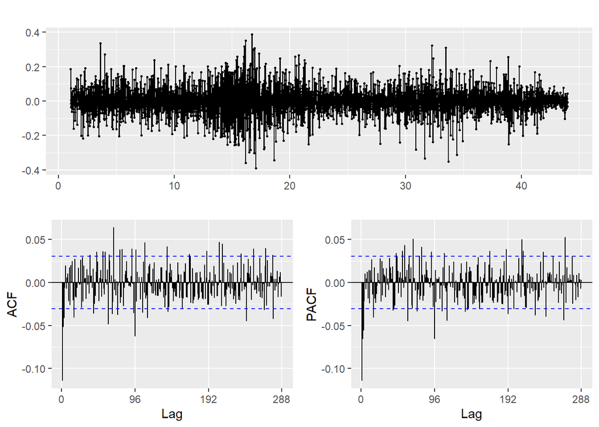

```r
ggtsdisplay(e)
```

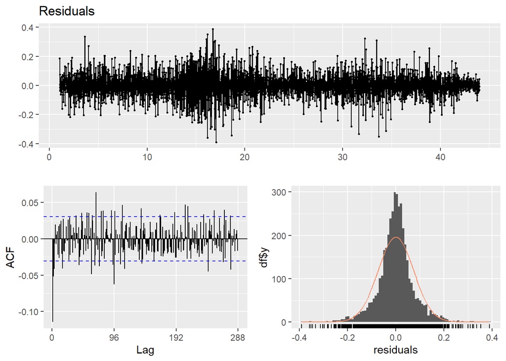

```
##
##  Ljung-Box test
##
## data:  Residuals
## Q* = 405.93, df = 192, p-value < 2.2e-16
##
## Model df: 0.   Total lags used: 192
```

```r
checkresiduals(e, plot = TRUE)
```

```r
exec_t_end = Sys.time()
print(exec_t_end - exec_t_start)
```

```
## Time difference of 15.59866 secs
```

```r
# saveRDS(fit, file = "XGBoost_weeky.rds")
```

## ML - PLS, 2 weeks history to forecast next day

```r
library(pls)
```

```r
# Code commented: very long model fitting, model performance not great

# exec_t_start = Sys.time()
#
# fit = plsr(df_2weeks[,(2*7*96+1):(2*7*96+96)] ~ df_2weeks[,1:(2*7*96)],
#            scale = TRUE,
#            validation = "CV")
# fit |>  summary()
#
# # Cross-validation results
# validation_mse <- fit$validation$PRESS
# avg_mse <- colMeans(validation_mse)
#
# # Optimal components minimizing average MSE
# optimal_ncomp <- which.min(avg_mse)
#
# e = fit$residuals[,,optimal_ncomp]
# print(paste0("Train RMSE: ", sqrt(mean(e^2, na.rm = TRUE))))
# # ggtsdisplay(e)
# # checkresiduals(e, plot = TRUE)
#
# exec_t_end = Sys.time()
# print(exec_t_end - exec_t_start)
#
# # saveRDS(fit, file = "PLS_2weeks.rds")
```

#### Notes:

- PLS: Very long fitting time (approx. 6h). And produces a huge model object (+11 GB)
- Train RMSE = 8.41923 (optimal_ncomp = 144)

## Model performance comparison on test set

### Models based on daily period

```r
# Build a list of models
models_list = list()
models_list$SARIMA_500_010_96 = readRDS('ARIMA_auto_(5,0,0)(0,1,0)[96].rds')
models_list$SARIMA_500_011_96 = readRDS('ARIMA_man_(5,0,0)(0,1,1)[96].rds')
models_list$SARIMA_1100_011_96 = readRDS('ARIMA_man_(11,0,0)(0,1,1)[96].rds')
models_list$NNetAR_daily = readRDS('NNetAR_daily.rds')
models_list$RF_daily = readRDS('RF_daily.rds')
models_list$XGBoots_daily = readRDS('XGBoost_daily.rds')

# Make predictions with each model and store RMSE
previsions_list = list()
rmsep_list = list()
horizon = 96
freq = 96
newdata_ML = tail(y_daily_train, horizon)

for (name in names(models_list))
{
  cat(paste0("Forcasting model:", name, "\n"))

  if(grepl("RF", name) | grepl("XG", name)) # Use forecast_ML() with ML models
  {
    prevision = forecast_ML(models_list[[name]],
                            newdata = matrix(newdata_ML,1),
                            horizon)
    prevision = ts(prevision,
                   start = start(y_daily_test),
                   frequency = freq)
  }
  else # Use forecast() with ts models
  {
    prevision = forecast(models_list[[name]], h = horizon)
    prevision = prevision$mean
  }

  previsions_list[[name]] = prevision
  rmsep_list[[name]] = RMSE(y_daily_test,prevision)

  cat(paste0("Test set RMSE: ", rmsep_list[[name]], "\n\n"))
}
```

```
## Forcasting model:SARIMA_500_010_96
## Test set RMSE: 5.86369104634429
##
## Forcasting model:SARIMA_500_011_96
## Test set RMSE: 12.0202823766086
##
## Forcasting model:SARIMA_1100_011_96
## Test set RMSE: 12.0282964300985
##
## Forcasting model:NNetAR_daily
## Test set RMSE: 24.0839486974642
##
## Forcasting model:RF_daily
## Test set RMSE: 7.54168190610469
##
## Forcasting model:XGBoots_daily
## Test set RMSE: 17.3911854416541
```

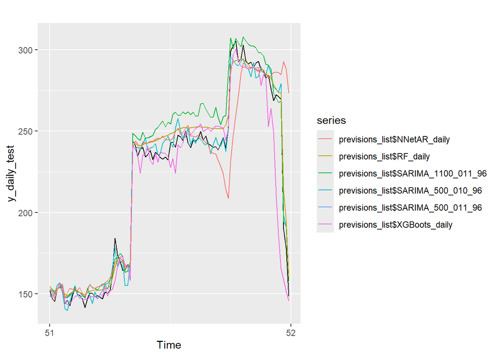

```r
# Plots
autoplot(y_daily_test) +
  autolayer(previsions_list$SARIMA_500_010_96) +
  autolayer(previsions_list$SARIMA_500_011_96) +
  autolayer(previsions_list$SARIMA_1100_011_96) +
  autolayer(previsions_list$NNetAR_daily) +
  autolayer(previsions_list$RF_daily) +
  autolayer(previsions_list$XGBoots_daily)
```

### Models based on weekly period

```r
# Build a list of models
models_list = list()
models_list$SARIMA_512_010_672 = readRDS('ARIMA_auto_(5,1,2)(0,1,0)[672].rds')
models_list$NNetAR_weekly = readRDS('NNetAR_weekly.rds')
models_list$RF_weekly = readRDS('RF_weekly.rds')
models_list$XGBoots_weekly = readRDS('XGBoost_weeky.rds')

# Make predictions with each model and store RMSE
previsions_list = list()
rmsep_list = list()
horizon = 96
freq = 7 * 96
newdata_ML = tail(y_weekly_train, 7*horizon)

for (name in names(models_list))
{
  cat(paste0("Forcasting model:", name, "\n"))

  if(grepl("RF", name) | grepl("XG", name)) # Use forecast_ML() with ML models
  {
    prevision = forecast_ML(models_list[[name]],
                            newdata = matrix(newdata_ML,1),
                            horizon)
    prevision = ts(prevision,
                   start = start(y_weekly_test),
                   frequency = freq)
  }
  else # Use forecast() with ts models
  {
    prevision = forecast(models_list[[name]], h = horizon)
    prevision = prevision$mean
  }

  previsions_list[[name]] = prevision
  rmsep_list[[name]] = RMSE(y_weekly_test,prevision)

  cat(paste0("Test set RMSE: ", rmsep_list[[name]], "\n\n"))
}
```

```
## Forcasting model:SARIMA_512_010_672
## Test set RMSE: 14.2221948483852
##
## Forcasting model:NNetAR_weekly
## Test set RMSE: 17.7976830162591
##
## Forcasting model:RF_weekly
## Test set RMSE: 12.4254243102076
##
## Forcasting model:XGBoots_weekly
## Test set RMSE: 11.3326364580346
```

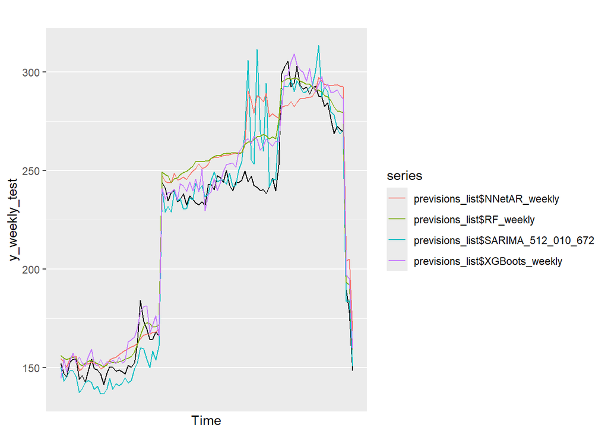

```r
# Plots
autoplot(y_weekly_test) +
  autolayer(previsions_list$SARIMA_512_010_672) +
  autolayer(previsions_list$NNetAR_weekly) +
  autolayer(previsions_list$RF_weekly) +
  autolayer(previsions_list$XGBoots_weekly)
```

```r
# Code commented: issue with prediction

# fit = readRDS("PLS_2weeks.rds")
#
# cat(paste0("Forcasting model:", "PLS_2weeks", "\n"))
#
# prevision = predict(fit,
#                     newdata = t(matrix(tail(y_weekly_train, 2*7*96), nrow = 1)),
#                     ncomp = 144)
# prevision = ts(prevision[1,,1], start = c(8,97), frequency = 7*96)
#
# RMSE_PLS_2weeks = RMSE(y_weekly_test,prevision)
# cat(paste0("Test set RMSE: ", RMSE_PLS_2weeks, "\n\n"))
#
# autoplot(y_weekly_test) +
#   autolayer(prevision)
```